# Return Home

View Code on Github

# Top European Football Teams Youtube Data EDA

## 1 Manchester United

commonly referred to as Man United (often stylised as Man Utd), or simply United, is a professional football club based in Old Trafford, Greater Manchester, England. The club competes in the Premier League, the top division in the English football league system. Nicknamed the Red Devils, they were founded as Newton Heath LYR Football Club in 1878, but changed their name to Manchester United in 1902. After a spell playing in Clayton, Manchester, the club moved to their current stadium, Old Trafford, in 1910.

## 2 Real Madrid

commonly referred to as Real Madrid, is a Spanish professional football club based in Madrid. The club competes in La Liga, the top tier of Spanish football. Founded in 1902 as Madrid Football Club, the club has traditionally worn a white home kit since its inception. The honorific title real is Spanish for "royal" and was bestowed to the club by King Alfonso XIII in 1920 together with the royal crown in the emblem

## 3 Barcelona FC

commonly referred to as and colloquially known as Barça ([ˈbaɾsə]), is a professional football club based in Barcelona, Catalonia, Spain, that competes in La Liga, the top flight of Spanish football. Founded in 1899 by a group of Swiss, Catalan, German, and English footballers led by Joan Gamper, the club has become a symbol of Catalan culture and Catalanism, hence the motto "Més que un club" ("More than a club").

## 4 FC Bayern Munich

Bayern Munich, or simply Bayern, is a German professional sports club based in Munich, Bavaria. It is best known for its professional men's association football team, which plays in the Bundesliga, the top tier of the German football league system. Bayern is the most successful club in German football history, having won a record 33 national titles, including eleven consecutively since 2013, and 20 national cups, along with numerous European honours.

## 5 Inter Milan

commonly referred to as Internazionale (pronounced [ˌinternattsjoˈnaːle]) or simply Inter, and colloquially known as Inter Milan in English-speaking countries,[8][9][10] is an Italian professional football club based in Milan, Lombardy. Inter is the only Italian side to have always competed in the top flight of Italian football since its debut in 1909.

## 6 Paris Saint-Germain F.C.

is a professional football club based in Paris, France. They compete in Ligue 1, the top division of French football. As France's most successful club, they have won over 40 official honours, including eleven league titles and one major European trophy. Their home ground is the Parc des Princes located in the 16th arrondissement of Paris near the commune Boulogne-Billancourt.

## 7 Rangers F.C.

Scottish professional football club based in the Govan district of Glasgow which plays in the Scottish Premiership. Although not its official name, it is often referred to as Glasgow Rangers outside Scotland.

## 8 Celtic F.C.

commonly known as Celtic (/ˈsɛltɪk/), is a Scottish professional football club based in Glasgow, which plays in the Scottish Premiership. The club was founded in 1887[nb 1] with the purpose of alleviating poverty in the immigrant Irish population in the East End of Glasgow.

```python
pip install google-api-python-client
```

```python
# lets import libraries
from googleapiclient.discovery import build
import pandas as pd
import seaborn as sns
```

## 1 Manchester United Channel Stats

## Function to get Manchester United channel statistics

```python
api_key = 'AIzaSyB24Kop04L1GlTgRCm1XtQ4KB2a4gaBOwA'
manchester_united_channel_id = ['UC6yW44UGJJBvYTlfC7CRg2Q' # Manchester United
              ]
youtube = build('youtube','v3',developerKey = api_key)

from googleapiclient.errors import HttpError

def get_channel_stats(youtube,manchester_united_channel_id):
    all_data = []
    try:
        request = youtube.channels().list(
            part='snippet,contentDetails,statistics',
            id=','.join(manchester_united_channel_id)
        )
        response = request.execute()

        for item in response.get('items', []):
            snippet = item.get('snippet', {})
            statistics = item.get('statistics', {})

            data = {
                'Channel_name': snippet.get('title', ''),
                'Subscribers': statistics.get('subscriberCount', ''),
                'Views': statistics.get('viewCount', ''),
                'Total_videos': statistics.get('videoCount', '')
            }

            all_data.append(data)

    except HttpError as e:
        print(f"HTTP error occurred: {e}")
        print(f"Request URL: {e.resp.request.url}")
        print(f"Request body: {e.resp.request.body}")

    return all_data
```

```python
get_channel_stats(youtube,manchester_united_channel_id)
```

```
[{'Channel_name': 'Manchester United',
  'Subscribers': '8560000',
  'Views': '1952014757',
  'Total_videos': '3796'}]
```

```python
channel_statistics = get_channel_stats(youtube, manchester_united_channel_id)
```

```python
manchester_united_channel_data =pd.DataFrame(channel_statistics)
```

```python
manchester_united_channel_data
```

|  | Channel_name | Subscribers | Views | Total_videos |
| --- | --- | --- | --- | --- |
| 0 | Manchester United | 8560000 | 1952014757 | 3796 |

# 2 Real Madrid FC Channel Stats

```python
api_key = 'AIzaSyB24Kop04L1GlTgRCm1XtQ4KB2a4gaBOwA'
Real_Madrid_id = ['UCWV3obpZVGgJ3j9FVhEjF2Q' # Real Madrid FC
              ]
youtube = build('youtube','v3',developerKey = api_key)
```

## Function to get Real Madrid FC channel statistics

```python
from googleapiclient.errors import HttpError

def get_channel_stats(youtube,Real_Madrid_id):
    all_data = []
    try:
        request = youtube.channels().list(
            part='snippet,contentDetails,statistics',
            id=','.join(Real_Madrid_id)
        )
        response = request.execute()

        for item in response.get('items', []):
            snippet = item.get('snippet', {})
            statistics = item.get('statistics', {})

            data = {
                'Channel_name': snippet.get('title', ''),
                'Subscribers': statistics.get('subscriberCount', ''),
                'Views': statistics.get('viewCount', ''),
                'Total_videos': statistics.get('videoCount', '')
            }

            all_data.append(data)

    except HttpError as e:
        print(f"HTTP error occurred: {e}")
        print(f"Request URL: {e.resp.request.url}")
        print(f"Request body: {e.resp.request.body}")

    return all_data
```

```python
get_channel_stats(youtube, Real_Madrid_id)
```

```
[{'Channel_name': 'Real Madrid',
  'Subscribers': '12100000',
  'Views': '1911178561',
  'Total_videos': '6597'}]
```

```python
Real_Madrid_channel_statistics = get_channel_stats(youtube,Real_Madrid_id)
```

```python
Real_Madrid_channel_data =pd.DataFrame(Real_Madrid_channel_statistics)
```

```python
Real_Madrid_channel_data
```

|  | Channel_name | Subscribers | Views | Total_videos |
| --- | --- | --- | --- | --- |
| 0 | Real Madrid | 12100000 | 1911178561 | 6597 |

# 3 Barcelona FC Channel Stats

## Functions to get Barcelona FC channel statistics

```python
api_key = 'AIzaSyB24Kop04L1GlTgRCm1XtQ4KB2a4gaBOwA'
Barcelona_FC_channel_id = ['UC14UlmYlSNiQCBe9Eookf_A'  # Barcelona FC

              ]
youtube = build('youtube','v3',developerKey = api_key)



from googleapiclient.errors import HttpError

def get_channel_stats(youtube, Barcelona_FC_channel_id ):
    all_data = []
    try:
        request = youtube.channels().list(
            part='snippet,contentDetails,statistics',
            id=','.join(Barcelona_FC_channel_id)
        )
        response = request.execute()

        for item in response.get('items', []):
            snippet = item.get('snippet', {})
            statistics = item.get('statistics', {})

            data = {
                'Channel_name': snippet.get('title', ''),
                'Subscribers': statistics.get('subscriberCount', ''),
                'Views': statistics.get('viewCount', ''),
                'Total_videos': statistics.get('videoCount', '')
            }

            all_data.append(data)

    except HttpError as e:
        print(f"HTTP error occurred: {e}")
        print(f"Request URL: {e.resp.request.url}")
        print(f"Request body: {e.resp.request.body}")

    return all_data
```

```python
get_channel_stats(youtube, Barcelona_FC_channel_id )
```

```
[{'Channel_name': 'FC Barcelona',
  'Subscribers': '16400000',
  'Views': '3096925255',
  'Total_videos': '11553'}]
```

```python
Barcelona_FC_channel_statistics = get_channel_stats(youtube,Barcelona_FC_channel_id)
```

```python
Barcelona_FC_channel_data =pd.DataFrame(Barcelona_FC_channel_statistics)
```

```python
Barcelona_FC_channel_data
```

|  | Channel_name | Subscribers | Views | Total_videos |
| --- | --- | --- | --- | --- |
| 0 | FC Barcelona | 16400000 | 3096925255 | 11553 |

## 4 FC Bayern Munich Channel Stats

## Functions to get Bayern Munich Channel statistics

```python
api_key = 'AIzaSyB24Kop04L1GlTgRCm1XtQ4KB2a4gaBOwA'
Bayern_Munich_channel_id = [ 'UCZkcxFIsqW5htimoUQKA0iA' # Bayern Munich

              ]
youtube = build('youtube','v3',developerKey = api_key)



from googleapiclient.errors import HttpError

def get_channel_stats(youtube, Bayern_Munich_channel_id ):
    all_data = []
    try:
        request = youtube.channels().list(
            part='snippet,contentDetails,statistics',
            id=','.join(Bayern_Munich_channel_id)
        )
        response = request.execute()

        for item in response.get('items', []):
            snippet = item.get('snippet', {})
            statistics = item.get('statistics', {})

            data = {
                'Channel_name': snippet.get('title', ''),
                'Subscribers': statistics.get('subscriberCount', ''),
                'Views': statistics.get('viewCount', ''),
                'Total_videos': statistics.get('videoCount', '')
            }

            all_data.append(data)

    except HttpError as e:
        print(f"HTTP error occurred: {e}")
        print(f"Request URL: {e.resp.request.url}")
        print(f"Request body: {e.resp.request.body}")

    return all_data
```

```python
get_channel_stats(youtube,Bayern_Munich_channel_id)
```

```
[{'Channel_name': 'FC Bayern München',
  'Subscribers': '3890000',
  'Views': '1724518383',
  'Total_videos': '5736'}]
```

```python
Bayern_Munich_channel_statistics = get_channel_stats(youtube, Bayern_Munich_channel_id)
```

```python
Bayern_Munich_channel_data =pd.DataFrame(Bayern_Munich_channel_statistics)
```

```python
Bayern_Munich_channel_data
```

|  | Channel_name | Subscribers | Views | Total_videos |
| --- | --- | --- | --- | --- |
| 0 | FC Bayern München | 3890000 | 1724518383 | 5736 |

# 5 InterMilan FC Channel Stats

## Functions to get InterMilan FC Channel statistics

```python
api_key = 'AIzaSyB24Kop04L1GlTgRCm1XtQ4KB2a4gaBOwA'
InterMilan_channel_id = [ 'UCvXzEblUa0cfny4HAJ_ZOWw'  #  InterMilan FC

              ]
youtube = build('youtube','v3',developerKey = api_key)



from googleapiclient.errors import HttpError

def get_channel_stats(youtube, InterMilan_channel_id):
    all_data = []
    try:
        request = youtube.channels().list(
            part='snippet,contentDetails,statistics',
            id=','.join(InterMilan_channel_id)
        )
        response = request.execute()

        for item in response.get('items', []):
            snippet = item.get('snippet', {})
            statistics = item.get('statistics', {})

            data = {
                'Channel_name': snippet.get('title', ''),
                'Subscribers': statistics.get('subscriberCount', ''),
                'Views': statistics.get('viewCount', ''),
                'Total_videos': statistics.get('videoCount', '')
            }

            all_data.append(data)

    except HttpError as e:
        print(f"HTTP error occurred: {e}")
        print(f"Request URL: {e.resp.request.url}")
        print(f"Request body: {e.resp.request.body}")

    return all_data
```

```python
get_channel_stats(youtube,InterMilan_channel_id )
```

```
[{'Channel_name': 'Inter',
  'Subscribers': '1290000',
  'Views': '513579511',
  'Total_videos': '10626'}]
```

```python
InterMilan_channel_statistics = get_channel_stats(youtube,InterMilan_channel_id)
```

```python
InterMilan_channel_data =pd.DataFrame(InterMilan_channel_statistics)
```

```python
InterMilan_channel_data
```

|  | Channel_name | Subscribers | Views | Total_videos |
| --- | --- | --- | --- | --- |
| 0 | Inter | 1290000 | 513579511 | 10626 |

# 6 Paris Saint-Germain Channel Stats

```python
api_key = 'AIzaSyB24Kop04L1GlTgRCm1XtQ4KB2a4gaBOwA'
Paris_Saint_Germain_channel_id = [ 'UCt9a_qP9CqHCNwilf-iULag'  #  Paris Saint-Germain

              ]
youtube = build('youtube','v3',developerKey = api_key)



from googleapiclient.errors import HttpError

def get_channel_stats(youtube,Paris_Saint_Germain_channel_id ):
    all_data = []
    try:
        request = youtube.channels().list(
            part='snippet,contentDetails,statistics',
            id=','.join(Paris_Saint_Germain_channel_id)
        )
        response = request.execute()

        for item in response.get('items', []):
            snippet = item.get('snippet', {})
            statistics = item.get('statistics', {})

            data = {
                'Channel_name': snippet.get('title', ''),
                'Subscribers': statistics.get('subscriberCount', ''),
                'Views': statistics.get('viewCount', ''),
                'Total_videos': statistics.get('videoCount', '')
            }

            all_data.append(data)

    except HttpError as e:
        print(f"HTTP error occurred: {e}")
        print(f"Request URL: {e.resp.request.url}")
        print(f"Request body: {e.resp.request.body}")

    return all_data
```

```python
get_channel_stats(youtube,Paris_Saint_Germain_channel_id)
```

```
[{'Channel_name': 'PSG - Paris Saint-Germain',
  'Subscribers': '7390000',
  'Views': '904123810',
  'Total_videos': '5625'}]
```

```python
Paris_Saint_Germain_channel_statistics = get_channel_stats(youtube, Paris_Saint_Germain_channel_id)
```

```python
Paris_Saint_Germain_channel_data =pd.DataFrame(Paris_Saint_Germain_channel_statistics)
```

```python
Paris_Saint_Germain_channel_data
```

|  | Channel_name | Subscribers | Views | Total_videos |
| --- | --- | --- | --- | --- |
| 0 | PSG - Paris Saint-Germain | 7390000 | 904123810 | 5625 |

# 7 Rangers Football Club Channel Stats

## Functions to get Rangers Football channel statistics

```python
api_key = 'AIzaSyB24Kop04L1GlTgRCm1XtQ4KB2a4gaBOwA'
Rangers_Football_channel_id = ['UCVaGyBPoEAZItDjlFPsRcSA'  # Rangers Football

              ]
youtube = build('youtube','v3',developerKey = api_key)



from googleapiclient.errors import HttpError

def get_channel_stats(youtube, Rangers_Football_channel_id ):
    all_data = []
    try:
        request = youtube.channels().list(
            part='snippet,contentDetails,statistics',
            id=','.join(Rangers_Football_channel_id)
        )
        response = request.execute()

        for item in response.get('items', []):
            snippet = item.get('snippet', {})
            statistics = item.get('statistics', {})

            data = {
                'Channel_name': snippet.get('title', ''),
                'Subscribers': statistics.get('subscriberCount', ''),
                'Views': statistics.get('viewCount', ''),
                'Total_videos': statistics.get('videoCount', '')
            }

            all_data.append(data)

    except HttpError as e:
        print(f"HTTP error occurred: {e}")
        print(f"Request URL: {e.resp.request.url}")
        print(f"Request body: {e.resp.request.body}")

    return all_data
```

```python
get_channel_stats(youtube, Rangers_Football_channel_id)
```

```
[{'Channel_name': 'Rangers Football Club (Official)',
  'Subscribers': '195000',
  'Views': '105320692',
  'Total_videos': '9319'}]
```

```python
Rangers_Football_statistics = get_channel_stats(youtube, Rangers_Football_channel_id)
```

```python
Rangers_Football_channel_data =pd.DataFrame(Rangers_Football_statistics)
```

```python
Rangers_Football_channel_data
```

|  | Channel_name | Subscribers | Views | Total_videos |
| --- | --- | --- | --- | --- |
| 0 | Rangers Football Club (Official) | 195000 | 105320692 | 9319 |

# 8 Celtic F.C.Channel Stats

## Functions to get Celtic F.C.Channel statistics

```python
api_key = 'AIzaSyB24Kop04L1GlTgRCm1XtQ4KB2a4gaBOwA'
Celtic_FC_Channel_id = [ 'UCBN-bb-hE7jYlcp4exwXRsQ' # Celtic F.C

              ]
youtube = build('youtube','v3',developerKey = api_key)



from googleapiclient.errors import HttpError

def get_channel_stats(youtube, Celtic_FC_Channel_id ):
    all_data = []
    try:
        request = youtube.channels().list(
            part='snippet,contentDetails,statistics',
            id=','.join(Celtic_FC_Channel_id)
        )
        response = request.execute()

        for item in response.get('items', []):
            snippet = item.get('snippet', {})
            statistics = item.get('statistics', {})

            data = {
                'Channel_name': snippet.get('title', ''),
                'Subscribers': statistics.get('subscriberCount', ''),
                'Views': statistics.get('viewCount', ''),
                'Total_videos': statistics.get('videoCount', '')
            }

            all_data.append(data)

    except HttpError as e:
        print(f"HTTP error occurred: {e}")
        print(f"Request URL: {e.resp.request.url}")
        print(f"Request body: {e.resp.request.body}")

    return all_data
```

```python
get_channel_stats(youtube, Celtic_FC_Channel_id)
```

```
[{'Channel_name': 'Celtic FC',
  'Subscribers': '226000',
  'Views': '96538338',
  'Total_videos': '4891'}]
```

```python
Celtic_FC_Channel_statistics = get_channel_stats(youtube, Celtic_FC_Channel_id)
```

```python
Celtic_FC_Channel_data =pd.DataFrame(Celtic_FC_Channel_statistics)
```

```python
Celtic_FC_Channel_data
```

|  | Channel_name | Subscribers | Views | Total_videos |
| --- | --- | --- | --- | --- |
| 0 | Celtic FC | 226000 | 96538338 | 4891 |

```python
# Combine DataFrames using concat
combined_european_football_channels_df = pd.concat([
                                        manchester_united_channel_data ,
                                     Real_Madrid_channel_data,
                                       Barcelona_FC_channel_data ,
                                      Bayern_Munich_channel_data ,
                                       InterMilan_channel_data,
                                  Paris_Saint_Germain_channel_data,
                                        Rangers_Football_channel_data,
                                        Celtic_FC_Channel_data

                                      ], ignore_index=True)

# Display the result
print(combined_european_football_channels_df)
```

```
                       Channel_name Subscribers       Views Total_videos
0                 Manchester United     8560000  1952014757         3796
1                       Real Madrid    12100000  1911178561         6597
2                      FC Barcelona    16400000  3096925255        11553
3                 FC Bayern München     3890000  1724518383         5736
4                             Inter     1290000   513579511        10626
5         PSG - Paris Saint-Germain     7390000   904123810         5625
6  Rangers Football Club (Official)      195000   105320692         9319
7                         Celtic FC      226000    96538338         4891
```

```python
# lets Shorten the Channel Names

import pandas as pd

# Assuming you already have the DataFrame named combined_european_football_channels_df

# Specify the maximum length for the channel names
max_length = 15

# Shorten the channel names in the "Channel_name" column
combined_european_football_channels_df['Channel_name'] = combined_european_football_channels_df['Channel_name'].apply(lambda x: x[:max_length])

# Display the updated DataFrame
print(combined_european_football_channels_df)


shortened_df = combined_european_football_channels_df.copy()
shortened_df['Channel_name'] = shortened_df['Channel_name'].apply(lambda x: x[:max_length])
shortened_df
```

[output not shown]

[output not shown]

```python
# lets have  a look at the datatypes
shortened_df.info()
```

[output not shown]

```python
# lets change the datatypes to perform  visualisations
shortened_df['Subscribers'] = pd.to_numeric(shortened_df['Subscribers'])
shortened_df['Views'] = pd.to_numeric(shortened_df['Views'])
shortened_df['Total_videos'] = pd.to_numeric(shortened_df['Total_videos'])
# letsconirm if the datatypes has changed
shortened_df.info()
```

[output not shown]

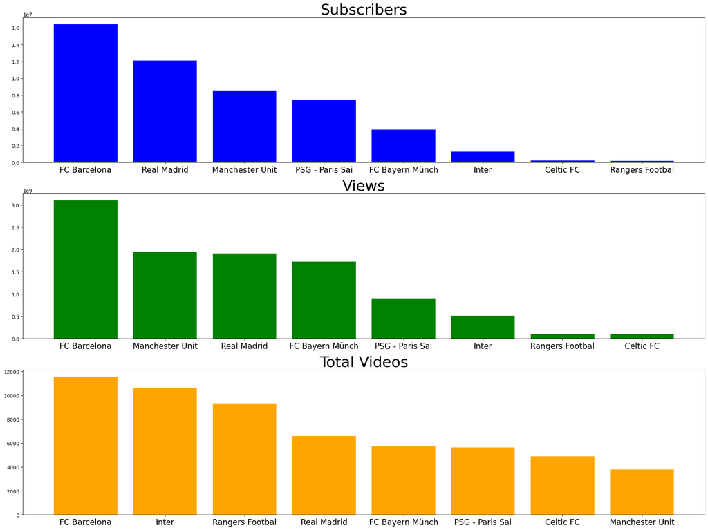

```python
import matplotlib.pyplot as plt

# Sort the DataFrame by 'Subscribers' in descending order
shortened_df_subscribers_sorted = shortened_df.sort_values(by='Subscribers', ascending=False)

# Plotting Subscribers in descending order
fig, axes = plt.subplots(nrows=3, ncols=1, figsize=(20, 15))

axes[0].bar(shortened_df_subscribers_sorted['Channel_name'],shortened_df_subscribers_sorted['Subscribers'], color='blue')
axes[0].set_title('Subscribers', fontsize=30)  # Adjust title font size as needed

# Sort the DataFrame by 'Views' in descending order
shortened_df_views_sorted = shortened_df.sort_values(by='Views', ascending=False)

# Plotting Views in descending order
axes[1].bar(shortened_df_views_sorted['Channel_name'], shortened_df_views_sorted['Views'], color='green')
axes[1].set_title('Views', fontsize=30)  # Adjust title font size as needed

# Sort the DataFrame by 'Total_videos' in descending order
shortened_df_total_videos_sorted = shortened_df.sort_values(by='Total_videos', ascending=False)

# Plotting Total Videos in descending order
axes[2].bar(shortened_df_total_videos_sorted['Channel_name'], shortened_df_total_videos_sorted['Total_videos'], color='orange')
axes[2].set_title('Total Videos', fontsize=30)  # Adjust title font size as needed

# Increase font size of x-axis labels
for ax in axes:
    ax.tick_params(axis='x',  labelsize=16)  # Adjust label rotation and font size as needed

# Adjust layout for better visibility
plt.tight_layout()

# Show the plot
plt.show()
```